# Berries Project

MA615, Fall 2020

Yuelin Jiang

10/18/2020

## Acquire and read the data

These data were collected from the USDA database selector: https://quickstats.nass.usda.gov

The data were [stored online](https://quickstats.nass.usda.gov/results/D416E96E-3D5C-324C-9334-1D38DF88FFF1) and then downloaded as a CSV file.

```r
## read the data

ag_data <- read_csv("berries.csv", col_names = TRUE)

## look at number of unique values in each column
ag_data %>% summarize_all(n_distinct) -> aa


## make a list of the columns with only one unique value
bb <- which(aa[1,]==1)

## list the 1-unique valu column names
cn <- colnames(ag_data)[bb]
```

Data selected from the NASS database often has columns without any data or with a single repeated Values. The berries data had only 8 out of 21 columns containing meaningful data. These first steps of cleaning codes are recycled from Haviland’s code in ag_data.rmd

```r
## remove the 1-unique columns from the dataset
ag_data %<>% select(-all_of(bb))

aa %<>% select(-all_of(bb))


## State name and the State ANSI code are (sort of) redundant
## Just keep the name
ag_data %<>% select(-4)
aa %<>% select(-4)


kable(head(ag_data)) %>% kable_styling(font_size=12)
```

Year

Period

State

Commodity

Data Item

Domain

Domain Category

Value

2019

MARKETING YEAR

CALIFORNIA

BLUEBERRIES

BLUEBERRIES, TAME - PRICE RECEIVED, MEASURED IN $ / LB

TOTAL

NOT SPECIFIED

2.85

2019

MARKETING YEAR

CALIFORNIA

BLUEBERRIES

BLUEBERRIES, TAME, FRESH MARKET - PRICE RECEIVED, MEASURED IN $ / LB

TOTAL

NOT SPECIFIED

3.56

2019

MARKETING YEAR

CALIFORNIA

BLUEBERRIES

BLUEBERRIES, TAME, PROCESSING - PRICE RECEIVED, MEASURED IN $ / LB

TOTAL

NOT SPECIFIED

0.29

2019

MARKETING YEAR

CALIFORNIA

RASPBERRIES

RASPBERRIES - PRICE RECEIVED, MEASURED IN $ / LB

TOTAL

NOT SPECIFIED

2.69

2019

MARKETING YEAR

CALIFORNIA

RASPBERRIES

RASPBERRIES, FRESH MARKET - PRICE RECEIVED, MEASURED IN $ / LB

TOTAL

NOT SPECIFIED

2019

MARKETING YEAR

CALIFORNIA

RASPBERRIES

RASPBERRIES, PROCESSING - PRICE RECEIVED, MEASURED IN $ / LB

TOTAL

NOT SPECIFIED

## Data Cleaning

Only selet strawberries as our commodity for EDA, and only select when period equals year.

```r
# Select strawberry as our fruit, and YEAR period for further analysis
sberry <- ag_data %>% dplyr::filter((Commodity=="STRAWBERRIES") & (Period=="YEAR"))
sberry %<>% select(-c(Commodity, Period))

# Check if every Data Item column begin with "STRAWBERRIES"
sum(str_detect(sberry$`Data Item`, "^STRAWBERRIES")) == length(sberry$`Data Item`)
```

```
## [1] TRUE
```

```r
# Remove "STRAWBERRIES" in the beginning of the Data Item column, drop this column
sberry %<>% separate(`Data Item`, c('straw', 'data_item'), sep = nchar("STRAWBERRIES")+2)
sberry %<>% select(-c(straw))

sberry %<>% separate(data_item, c('what', 'measure', 'how'), sep = ",")


# Notice when 'what' == 'PROCESSING', "MEASURED IN.." is in 'how' column. Switch the content for these rows.
sberry %<>% mutate(measure = ifelse(what == "PROCESSING", how, measure))
sberry %<>% mutate(how = ifelse(what == "PROCESSING", "", how))

# Repeat the above process for 'what' == 'FRESH MARKET'
sberry %<>% mutate(what = ifelse(what == "FRESH MARKET", "FRESH MARKET - UTILIZED - PRODUCTION", what))
sberry %<>% mutate(measure = ifelse(what == "FRESH MARKET - UTILIZED - PRODUCTION", how, measure))
sberry %<>% mutate(how = ifelse(what == "FRESH MARKET - UTILIZED - PRODUCTION", "", how))

# If measure column starts with "MEASURED IN", get rid of it, only unit is left.

sberry %<>% mutate(measure = ifelse(str_detect(sberry$measure, "^ MEASURED IN "), substr(sberry$measure, nchar(" MEASURED IN ")+1, nchar(sberry$measure))))

names(sberry)[4] <- paste("unit")

# delete useless column, fill NA value
sberry %<>% select(-c(how))
sberry[is.na(sberry)] <-""

# Check if all unit is in the correst format
sberry$unit %>% unique()
```

```
##  [1] ""                        "$"
##  [3] "CWT"                     "CWT / ACRE"
##  [5] "LB"                      "LB / ACRE / APPLICATION"
##  [7] "LB / ACRE / YEAR"        "NUMBER"
##  [9] "PCT OF AREA BEARING"     "TONS"
```

```r
# Check header of current dataframe
kable(head(sberry)) %>% kable_styling(font_size=12)
```

| Year | State | what | unit | Domain | Domain Category | Value |
| --- | --- | --- | --- | --- | --- | --- |
| 2019 | CALIFORNIA | ACRES HARVESTED |  | TOTAL | NOT SPECIFIED | 35,400 |
| 2019 | CALIFORNIA | ACRES PLANTED |  | TOTAL | NOT SPECIFIED | 36,000 |
| 2019 | CALIFORNIA | PRODUCTION | $ | TOTAL | NOT SPECIFIED | 2,221,320,000 |
| 2019 | CALIFORNIA | PRODUCTION | CWT | TOTAL | NOT SPECIFIED | 20,500,000 |
| 2019 | CALIFORNIA | YIELD | CWT / ACRE | TOTAL | NOT SPECIFIED | 580 |
| 2019 | CALIFORNIA | BEARING - APPLICATIONS | LB | CHEMICAL, FUNGICIDE | CHEMICAL, FUNGICIDE: (AZOXYSTROBIN = 128810) | 5,500 |

Now work on separating the ‘Domain’ and ‘Domain Category’ columns into meaningful columns.

```r
# Separate the Domain column by ","
sberry %<>% separate(Domain, c('domain1', 'domain2'), sep = ",")

# separate Domain Category by "," and ":"

sberry %<>% separate(`Domain Category`, c('dc1', 'dc2', 'dc_detail'), sep = "[,\\:]", convert = TRUE, extra = "merge")


sberry[is.na(sberry)] <- ""
kable(head(sberry)) %>% kable_styling(font_size=12)
```

| Year | State | what | unit | domain1 | domain2 | dc1 | dc2 | dc_detail | Value |
| --- | --- | --- | --- | --- | --- | --- | --- | --- | --- |
| 2019 | CALIFORNIA | ACRES HARVESTED |  | TOTAL |  | NOT SPECIFIED |  |  | 35,400 |
| 2019 | CALIFORNIA | ACRES PLANTED |  | TOTAL |  | NOT SPECIFIED |  |  | 36,000 |
| 2019 | CALIFORNIA | PRODUCTION | $ | TOTAL |  | NOT SPECIFIED |  |  | 2,221,320,000 |
| 2019 | CALIFORNIA | PRODUCTION | CWT | TOTAL |  | NOT SPECIFIED |  |  | 20,500,000 |
| 2019 | CALIFORNIA | YIELD | CWT / ACRE | TOTAL |  | NOT SPECIFIED |  |  | 580 |
| 2019 | CALIFORNIA | BEARING - APPLICATIONS | LB | CHEMICAL | FUNGICIDE | CHEMICAL | FUNGICIDE | (AZOXYSTROBIN = 128810) | 5,500 |

Save sberry to csv file for shiny app use.

```r
write.csv(sberry, "sberry_cleaned.csv")
```

## Exploratory Data Analysis

### Total Production Data for each state across the years

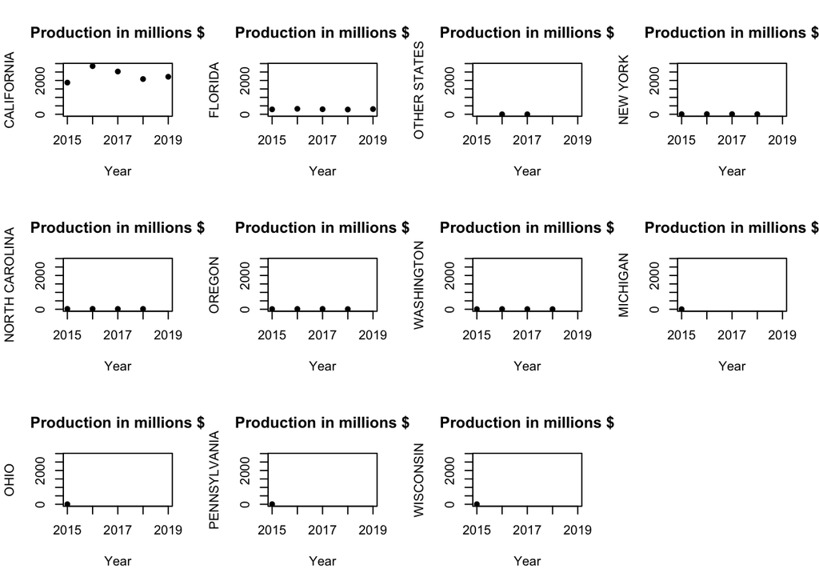

```r
d_total <- subset(sberry, domain1 == "TOTAL")

# Subset where unit is in $
usd <- subset(d_total, unit == "$")
test <- usd

# Set value to numeric
usd$Value <- as.numeric(gsub(pattern = ",", replacement = "",usd$Value))
usd[is.na(usd)] <- 0

# Prepare dataset of production for plots
prod <- subset(usd, what == " PRODUCTION" )

# Plot production by each state
par(mfrow = c(3,4))
state_list <- d_total$State %>% unique()

for (i in state_list) {
  stateTotal <- subset(prod, State == i)
  plot(x =stateTotal$Year, y = stateTotal$Value/1000000, xlab="Year", ylab=paste(i),
       title(main = "Production in millions $"), pch =16, ylim =c(0, 2900), xlim = c(2015, 2019))
}
```

The above graphs show that California has the highest value of strawberry productions over the years 2015 to 2019, Florida has the second highest production value.

### Relationship between amount of fertilizers and yield per acre.

```r
# Prepare database for yield plots
yield <- subset(d_total, what == " YIELD" )


# # Make values numeric
# yield %<>% mutate(Value = ifelse(Value=="(NA)", "0", Value) )
# yield$Value %<>% as.numeric(yield$Value)
# # class(yield$Value)

# Prepare database for fertilizer used, unit LB/ARE/YEAR
fert <- subset(sberry, domain1 =="FERTILIZER" & unit == "LB / ACRE / YEAR")

# Since fertilizer data only exists for california and florida in year 2018 and 2019,
yield <- subset(d_total, what == " YIELD" & (State == "CALIFORNIA" | State== "FLORIDA")& (Year=="2019" |Year=="2018") )
yield$Value <- as.numeric(yield$Value)

fert$yield <- NA
statelist<- fert%>% unique()


# fill each state's total yield by the yield table
for (i in 1:15) {
  if (fert$Year[i]=="2018"){
    if(fert$State[i]=="CALIFORNIA"){
      fert$yield[i] <- yield[3,10]
    } else {
      fert$yield[i] <- yield[4,10]
    }
  } else {
    if(fert$State[i]=="CALIFORNIA"){
      fert$yield[i] <- yield[1,10]
    } else{
      fert$yield[i] <- yield[2,10]
    }
  }
}
# make values numeric
fert$Value<- as.numeric(fert$Value)
fert[is.na(fert)] <- 0
fert$yield <- as.numeric(fert$yield)
class(fert$yield)
```

```
## [1] "numeric"
```

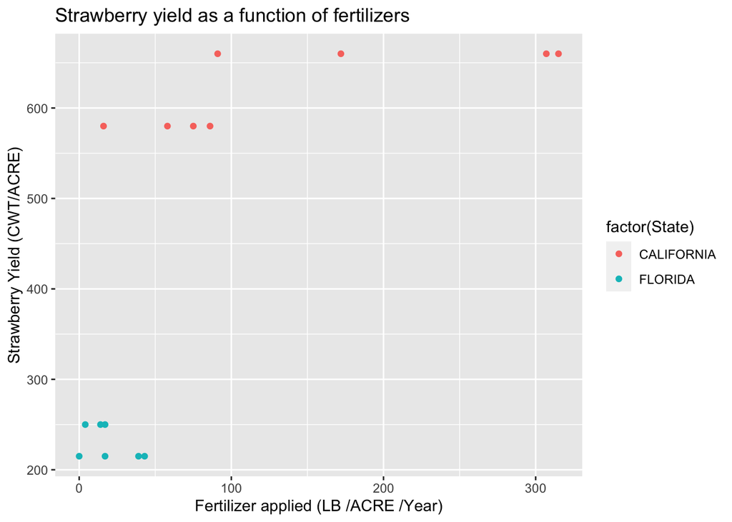

```r
ggplot(data = fert)+
  geom_point(aes(x= Value, y= yield,  color = factor(State)) )+
  labs(title = "Strawberry yield as a function of fertilizers", x = "Fertilizer applied (LB /ACRE /Year)", y = "Strawberry Yield (CWT/ACRE)")
```

We can observe from the above graph that, California in general uses way more fertilizers per acre per year than Florida, and has more Strawberry Yield per acre than Florida too. This EDA suggests potential further study on fertilizer yield and berry yield.

### Chemicals used

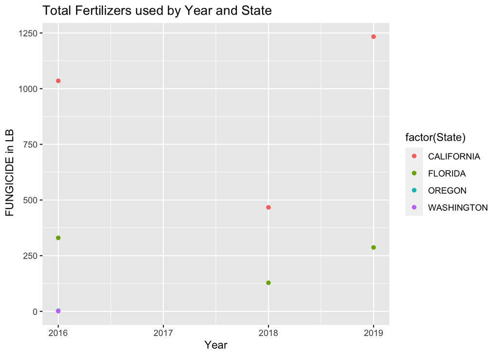

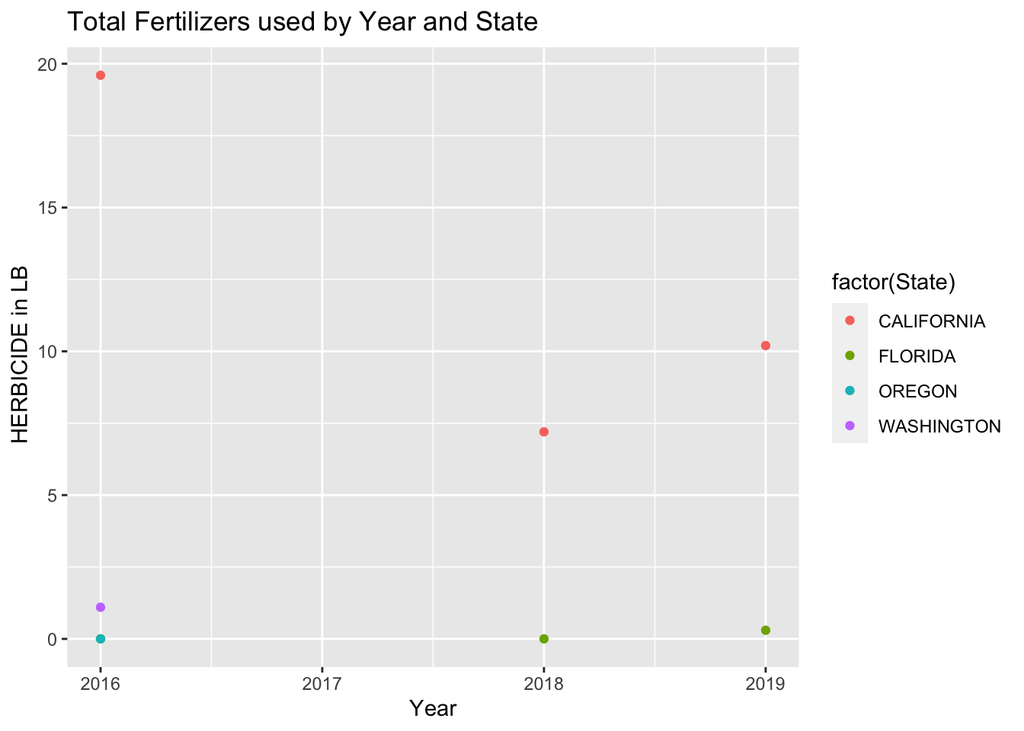

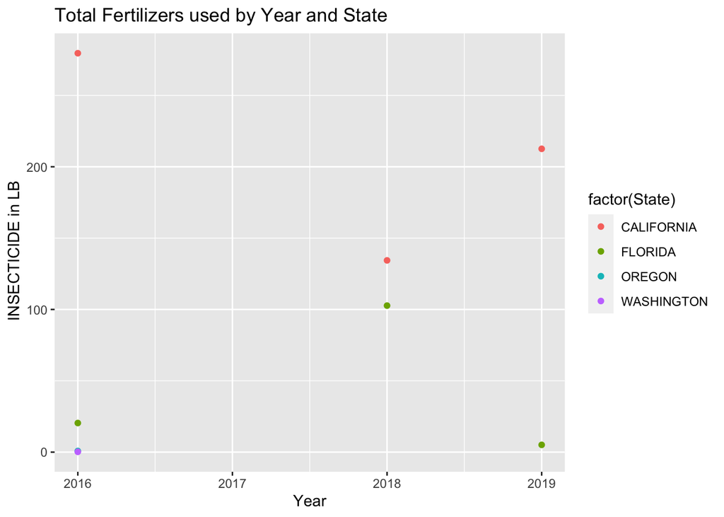

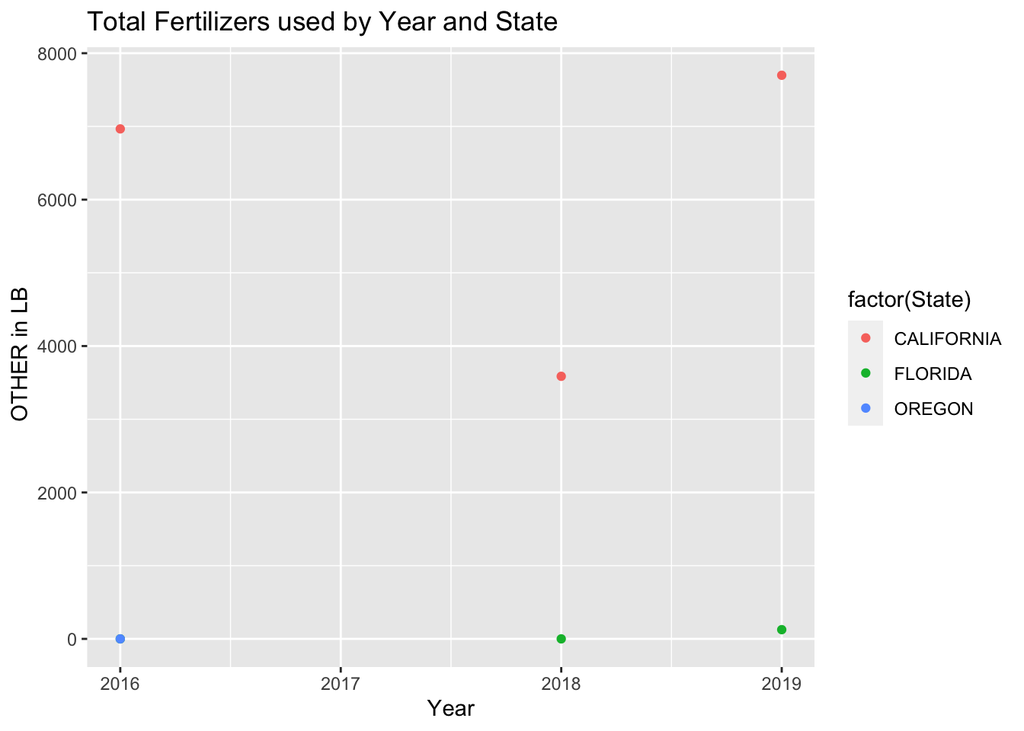

```r
# Dataframe of total amount of chemicals used

chemi <- subset(sberry, dc_detail ==" (TOTAL)")

chemi$Value <-as.numeric(gsub(pattern = ",", replacement = "",chemi$Value))


chemi[is.na(chemi)] <- 0
state_chemi <- chemi$State %>% unique()

# subsetting chemi into total chemical used and percentage of land used by unit
chemi_pct <- subset(chemi, unit == "PCT OF AREA BEARING")
chemi_lb <- subset(chemi,  unit == "LB")


che <- chemi$dc2 %>% unique()
# plot each state's use of different chemicals
for (c in che) {
  cData <- subset(chemi_lb, dc2==c)

  chemiPlot <- ggplot(data = cData)+
              geom_point(aes(x = Year, y = Value/1000, color = factor(State)))+
              labs(title = "Total Fertilizers used by Year and State", y = paste(c, "in LB") )+
              xlim(c(2016,2019))

  print(chemiPlot)
}
```

From the above plots, we can observe that California uses more Chemicals in total. Since California has the highest amount of planted strawberries, this is within expectation. Further analysis could investigate whether the use of each chemical per acre has any effect on the berry yield per acre.

## Reference

This project references to Haviland’s codes of data acquiring and reading, and receives help from Zhiwei Liang and Chenxun Li about how to transform characters to numeric forms, and what type of visualizations to implement.

This berries project uses packages tidyverse(Wickham et al., 2019), ggplot2(H. Wickham, 2016), kableExtra(Hao Zhu, 2020), and magrittr(S. M. Bache and H. Wickham, 2014) for data cleaning. The final report is complied by knitr(Yihui Xie, 2020), app is built using package shiny(Winston Chang, Joe Cheng, JJ Allaire, Yihui Xie and Jonathan McPherson, 2020)